# happiness report analysis and visualisation

### World Happiness Report Data Analysis and Visualization

Data has been retreived from Kaggle: https://www.kaggle.com/datasets/unsdsn/world-happiness?select=2019.csv

```python
import pandas as pd
import numpy as np
import seaborn as sns
import matplotlib.pyplot as plt
```

```python
df2015 = pd.read_csv('2015.csv')
```

```python
df2015.head()
```

|  | Country | Region | Happiness Rank | Happiness Score | Standard Error | Economy (GDP per Capita) | Family | Health (Life Expectancy) | Freedom | Trust (Government Corruption) | Generosity | Dystopia Residual |
| --- | --- | --- | --- | --- | --- | --- | --- | --- | --- | --- | --- | --- |
| 0 | Switzerland | Western Europe | 1 | 7.587 | 0.03411 | 1.39651 | 1.34951 | 0.94143 | 0.66557 | 0.41978 | 0.29678 | 2.51738 |
| 1 | Iceland | Western Europe | 2 | 7.561 | 0.04884 | 1.30232 | 1.40223 | 0.94784 | 0.62877 | 0.14145 | 0.43630 | 2.70201 |
| 2 | Denmark | Western Europe | 3 | 7.527 | 0.03328 | 1.32548 | 1.36058 | 0.87464 | 0.64938 | 0.48357 | 0.34139 | 2.49204 |
| 3 | Norway | Western Europe | 4 | 7.522 | 0.03880 | 1.45900 | 1.33095 | 0.88521 | 0.66973 | 0.36503 | 0.34699 | 2.46531 |
| 4 | Canada | North America | 5 | 7.427 | 0.03553 | 1.32629 | 1.32261 | 0.90563 | 0.63297 | 0.32957 | 0.45811 | 2.45176 |

```python
df2015.shape
```

```
(158, 12)
```

```python
df2015.dtypes
```

```
Country                           object
Region                            object
Happiness Rank                     int64
Happiness Score                  float64
Standard Error                   float64
Economy (GDP per Capita)         float64
Family                           float64
Health (Life Expectancy)         float64
Freedom                          float64
Trust (Government Corruption)    float64
Generosity                       float64
Dystopia Residual                float64
dtype: object
```

```python
df2015.describe().T
```

|  | count | mean | std | min | 25% | 50% | 75% | max |
| --- | --- | --- | --- | --- | --- | --- | --- | --- |
| Happiness Rank | 158.0 | 79.493671 | 45.754363 | 1.00000 | 40.250000 | 79.500000 | 118.750000 | 158.00000 |
| Happiness Score | 158.0 | 5.375734 | 1.145010 | 2.83900 | 4.526000 | 5.232500 | 6.243750 | 7.58700 |
| Standard Error | 158.0 | 0.047885 | 0.017146 | 0.01848 | 0.037268 | 0.043940 | 0.052300 | 0.13693 |
| Economy (GDP per Capita) | 158.0 | 0.846137 | 0.403121 | 0.00000 | 0.545808 | 0.910245 | 1.158448 | 1.69042 |
| Family | 158.0 | 0.991046 | 0.272369 | 0.00000 | 0.856823 | 1.029510 | 1.214405 | 1.40223 |
| Health (Life Expectancy) | 158.0 | 0.630259 | 0.247078 | 0.00000 | 0.439185 | 0.696705 | 0.811013 | 1.02525 |
| Freedom | 158.0 | 0.428615 | 0.150693 | 0.00000 | 0.328330 | 0.435515 | 0.549092 | 0.66973 |
| Trust (Government Corruption) | 158.0 | 0.143422 | 0.120034 | 0.00000 | 0.061675 | 0.107220 | 0.180255 | 0.55191 |
| Generosity | 158.0 | 0.237296 | 0.126685 | 0.00000 | 0.150553 | 0.216130 | 0.309883 | 0.79588 |
| Dystopia Residual | 158.0 | 2.098977 | 0.553550 | 0.32858 | 1.759410 | 2.095415 | 2.462415 | 3.60214 |

```python
df2015.isnull().any()
```

```
Country                          False
Region                           False
Happiness Rank                   False
Happiness Score                  False
Standard Error                   False
Economy (GDP per Capita)         False
Family                           False
Health (Life Expectancy)         False
Freedom                          False
Trust (Government Corruption)    False
Generosity                       False
Dystopia Residual                False
dtype: bool
```

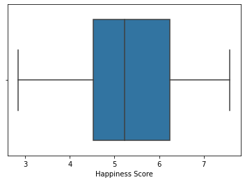

```python
sns.boxplot(data = df2015, x = df2015['Happiness Score']);
```

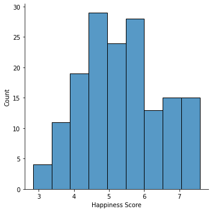

```python
sns.displot(data = df2015, x = df2015['Happiness Score']);
```

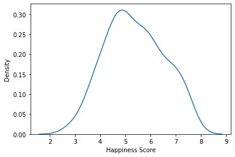

```python
sns.kdeplot(data = df2015, x = df2015['Happiness Score']);
```

```python
df2015.corr()
```

|  | Happiness Rank | Happiness Score | Standard Error | Economy (GDP per Capita) | Family | Health (Life Expectancy) | Freedom | Trust (Government Corruption) | Generosity | Dystopia Residual |
| --- | --- | --- | --- | --- | --- | --- | --- | --- | --- | --- |
| Happiness Rank | 1.000000 | -0.992105 | 0.158516 | -0.785267 | -0.733644 | -0.735613 | -0.556886 | -0.372315 | -0.160142 | -0.521999 |
| Happiness Score | -0.992105 | 1.000000 | -0.177254 | 0.780966 | 0.740605 | 0.724200 | 0.568211 | 0.395199 | 0.180319 | 0.530474 |
| Standard Error | 0.158516 | -0.177254 | 1.000000 | -0.217651 | -0.120728 | -0.310287 | -0.129773 | -0.178325 | -0.088439 | 0.083981 |
| Economy (GDP per Capita) | -0.785267 | 0.780966 | -0.217651 | 1.000000 | 0.645299 | 0.816478 | 0.370300 | 0.307885 | -0.010465 | 0.040059 |
| Family | -0.733644 | 0.740605 | -0.120728 | 0.645299 | 1.000000 | 0.531104 | 0.441518 | 0.205605 | 0.087513 | 0.148117 |
| Health (Life Expectancy) | -0.735613 | 0.724200 | -0.310287 | 0.816478 | 0.531104 | 1.000000 | 0.360477 | 0.248335 | 0.108335 | 0.018979 |
| Freedom | -0.556886 | 0.568211 | -0.129773 | 0.370300 | 0.441518 | 0.360477 | 1.000000 | 0.493524 | 0.373916 | 0.062783 |
| Trust (Government Corruption) | -0.372315 | 0.395199 | -0.178325 | 0.307885 | 0.205605 | 0.248335 | 0.493524 | 1.000000 | 0.276123 | -0.033105 |
| Generosity | -0.160142 | 0.180319 | -0.088439 | -0.010465 | 0.087513 | 0.108335 | 0.373916 | 0.276123 | 1.000000 | -0.101301 |
| Dystopia Residual | -0.521999 | 0.530474 | 0.083981 | 0.040059 | 0.148117 | 0.018979 | 0.062783 | -0.033105 | -0.101301 | 1.000000 |

```python
corr = df2015.corr()
```

```python
corr = corr['Happiness Score']
```

```python
corr = pd.DataFrame(data = corr)
```

```python
corr
```

|  | Happiness Score |
| --- | --- |
| Happiness Rank | -0.992105 |
| Happiness Score | 1.000000 |
| Standard Error | -0.177254 |
| Economy (GDP per Capita) | 0.780966 |
| Family | 0.740605 |
| Health (Life Expectancy) | 0.724200 |
| Freedom | 0.568211 |
| Trust (Government Corruption) | 0.395199 |
| Generosity | 0.180319 |
| Dystopia Residual | 0.530474 |

```python
corr.reset_index(inplace = True)
```

```python
corr
```

|  | index | Happiness Score |
| --- | --- | --- |
| 0 | Happiness Rank | -0.992105 |
| 1 | Happiness Score | 1.000000 |
| 2 | Standard Error | -0.177254 |
| 3 | Economy (GDP per Capita) | 0.780966 |
| 4 | Family | 0.740605 |
| 5 | Health (Life Expectancy) | 0.724200 |
| 6 | Freedom | 0.568211 |
| 7 | Trust (Government Corruption) | 0.395199 |
| 8 | Generosity | 0.180319 |
| 9 | Dystopia Residual | 0.530474 |

```python
corr = corr.iloc[3:9,]
```

```python
corr
```

|  | index | Happiness Score |
| --- | --- | --- |
| 3 | Economy (GDP per Capita) | 0.780966 |
| 4 | Family | 0.740605 |
| 5 | Health (Life Expectancy) | 0.724200 |
| 6 | Freedom | 0.568211 |
| 7 | Trust (Government Corruption) | 0.395199 |
| 8 | Generosity | 0.180319 |

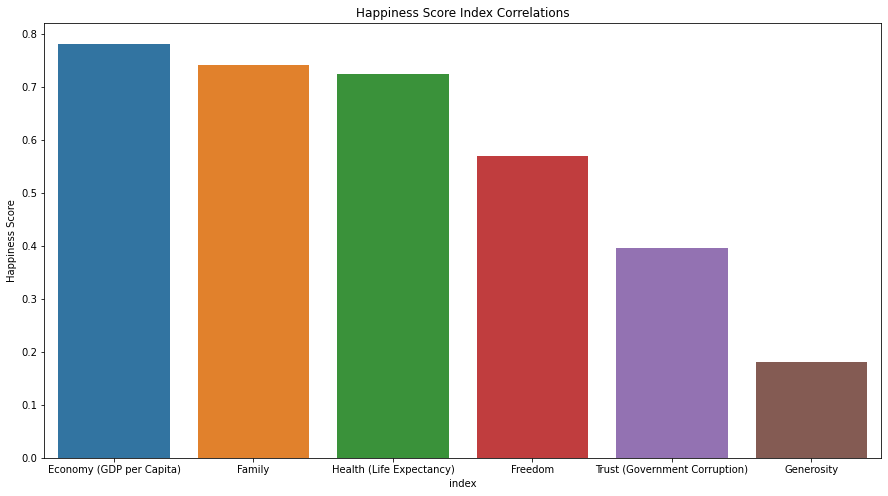

```python
ax = plt.figure(figsize=(15,8));
sns.barplot(data = corr, x = corr['index'], y = corr['Happiness Score']).set_title('Happiness Score Index Correlations');
```

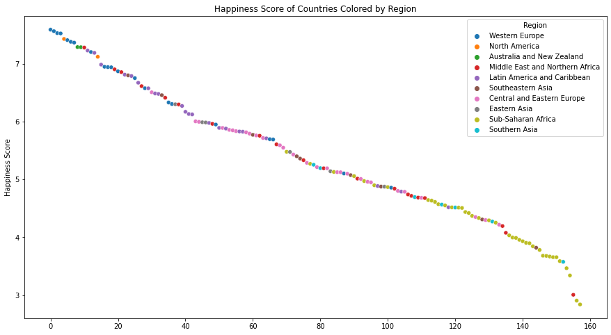

```python
ax = plt.figure(figsize=(15,8));
sns.scatterplot(data = df2015, x = df2015.index , y = df2015['Happiness Score'], hue = df2015['Region']).set_title('Happiness Score of Countries Colored by Region');
```

```python
region = df2015.groupby(['Region'])['Happiness Score'].mean()
```

```python
region = pd.DataFrame(region)
```

```python
region
```

| Region | Happiness Score |
| --- | --- |
| Australia and New Zealand | 7.285000 |
| Central and Eastern Europe | 5.332931 |
| Eastern Asia | 5.626167 |
| Latin America and Caribbean | 6.144682 |
| Middle East and Northern Africa | 5.406900 |
| North America | 7.273000 |
| Southeastern Asia | 5.317444 |
| Southern Asia | 4.580857 |
| Sub-Saharan Africa | 4.202800 |
| Western Europe | 6.689619 |

```python
region.reset_index(inplace = True)
```

```python
region
```

|  | Region | Happiness Score |
| --- | --- | --- |
| 0 | Australia and New Zealand | 7.285000 |
| 1 | Central and Eastern Europe | 5.332931 |
| 2 | Eastern Asia | 5.626167 |
| 3 | Latin America and Caribbean | 6.144682 |
| 4 | Middle East and Northern Africa | 5.406900 |
| 5 | North America | 7.273000 |
| 6 | Southeastern Asia | 5.317444 |
| 7 | Southern Asia | 4.580857 |
| 8 | Sub-Saharan Africa | 4.202800 |
| 9 | Western Europe | 6.689619 |

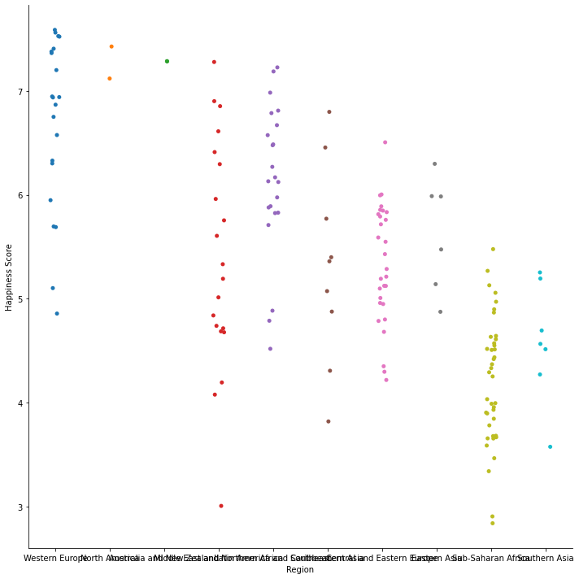

```python
sns.catplot(x ='Region', y = 'Happiness Score', data = df2015, height=10, aspect=1);
```

```python
df2015 = df2015.add_suffix('_2015')
```

```python
df2015.rename(columns={"Country_2015": "Country"}, inplace = True)
```

```python
df2015.head()
```

|  | Country | Region_2015 | Happiness Rank_2015 | Happiness Score_2015 | Standard Error_2015 | Economy (GDP per Capita)_2015 | Family_2015 | Health (Life Expectancy)_2015 | Freedom_2015 | Trust (Government Corruption)_2015 | Generosity_2015 | Dystopia Residual_2015 |
| --- | --- | --- | --- | --- | --- | --- | --- | --- | --- | --- | --- | --- |
| 0 | Switzerland | Western Europe | 1 | 7.587 | 0.03411 | 1.39651 | 1.34951 | 0.94143 | 0.66557 | 0.41978 | 0.29678 | 2.51738 |
| 1 | Iceland | Western Europe | 2 | 7.561 | 0.04884 | 1.30232 | 1.40223 | 0.94784 | 0.62877 | 0.14145 | 0.43630 | 2.70201 |
| 2 | Denmark | Western Europe | 3 | 7.527 | 0.03328 | 1.32548 | 1.36058 | 0.87464 | 0.64938 | 0.48357 | 0.34139 | 2.49204 |
| 3 | Norway | Western Europe | 4 | 7.522 | 0.03880 | 1.45900 | 1.33095 | 0.88521 | 0.66973 | 0.36503 | 0.34699 | 2.46531 |
| 4 | Canada | North America | 5 | 7.427 | 0.03553 | 1.32629 | 1.32261 | 0.90563 | 0.63297 | 0.32957 | 0.45811 | 2.45176 |

```python
df2016 = pd.read_csv('2016.csv')
```

```python
df2016.head()
```

|  | Country | Region | Happiness Rank | Happiness Score | Lower Confidence Interval | Upper Confidence Interval | Economy (GDP per Capita) | Family | Health (Life Expectancy) | Freedom | Trust (Government Corruption) | Generosity | Dystopia Residual |
| --- | --- | --- | --- | --- | --- | --- | --- | --- | --- | --- | --- | --- | --- |
| 0 | Denmark | Western Europe | 1 | 7.526 | 7.460 | 7.592 | 1.44178 | 1.16374 | 0.79504 | 0.57941 | 0.44453 | 0.36171 | 2.73939 |
| 1 | Switzerland | Western Europe | 2 | 7.509 | 7.428 | 7.590 | 1.52733 | 1.14524 | 0.86303 | 0.58557 | 0.41203 | 0.28083 | 2.69463 |
| 2 | Iceland | Western Europe | 3 | 7.501 | 7.333 | 7.669 | 1.42666 | 1.18326 | 0.86733 | 0.56624 | 0.14975 | 0.47678 | 2.83137 |
| 3 | Norway | Western Europe | 4 | 7.498 | 7.421 | 7.575 | 1.57744 | 1.12690 | 0.79579 | 0.59609 | 0.35776 | 0.37895 | 2.66465 |
| 4 | Finland | Western Europe | 5 | 7.413 | 7.351 | 7.475 | 1.40598 | 1.13464 | 0.81091 | 0.57104 | 0.41004 | 0.25492 | 2.82596 |

```python
df2016 = df2016.add_suffix('_2016')
```

```python
df2016.rename(columns={"Country_2016": "Country"}, inplace = True)
```

```python
df2016.columns
```

```
Index(['Country', 'Region_2016', 'Happiness Rank_2016', 'Happiness Score_2016',
       'Lower Confidence Interval_2016', 'Upper Confidence Interval_2016',
       'Economy (GDP per Capita)_2016', 'Family_2016',
       'Health (Life Expectancy)_2016', 'Freedom_2016',
       'Trust (Government Corruption)_2016', 'Generosity_2016',
       'Dystopia Residual_2016'],
      dtype='object')
```

Standart Error is divided into upper and lowel, this is why 2016 data have one more column

```python
df2015.columns
```

```
Index(['Country', 'Region_2015', 'Happiness Rank_2015', 'Happiness Score_2015',
       'Standard Error_2015', 'Economy (GDP per Capita)_2015', 'Family_2015',
       'Health (Life Expectancy)_2015', 'Freedom_2015',
       'Trust (Government Corruption)_2015', 'Generosity_2015',
       'Dystopia Residual_2015'],
      dtype='object')
```

```python
df2016.shape
```

```
(157, 13)
```

```python
df = df2015.merge(df2016, on='Country', how = 'left')
```

```python
df.head()
```

|  | Country | Region_2015 | Happiness Rank_2015 | Happiness Score_2015 | Standard Error_2015 | Economy (GDP per Capita)_2015 | Family_2015 | Health (Life Expectancy)_2015 | Freedom_2015 | Trust (Government Corruption)_2015 | ... | Happiness Score_2016 | Lower Confidence Interval_2016 | Upper Confidence Interval_2016 | Economy (GDP per Capita)_2016 | Family_2016 | Health (Life Expectancy)_2016 | Freedom_2016 | Trust (Government Corruption)_2016 | Generosity_2016 | Dystopia Residual_2016 |
| --- | --- | --- | --- | --- | --- | --- | --- | --- | --- | --- | --- | --- | --- | --- | --- | --- | --- | --- | --- | --- | --- |
| 0 | Switzerland | Western Europe | 1 | 7.587 | 0.03411 | 1.39651 | 1.34951 | 0.94143 | 0.66557 | 0.41978 | ... | 7.509 | 7.428 | 7.590 | 1.52733 | 1.14524 | 0.86303 | 0.58557 | 0.41203 | 0.28083 | 2.69463 |
| 1 | Iceland | Western Europe | 2 | 7.561 | 0.04884 | 1.30232 | 1.40223 | 0.94784 | 0.62877 | 0.14145 | ... | 7.501 | 7.333 | 7.669 | 1.42666 | 1.18326 | 0.86733 | 0.56624 | 0.14975 | 0.47678 | 2.83137 |
| 2 | Denmark | Western Europe | 3 | 7.527 | 0.03328 | 1.32548 | 1.36058 | 0.87464 | 0.64938 | 0.48357 | ... | 7.526 | 7.460 | 7.592 | 1.44178 | 1.16374 | 0.79504 | 0.57941 | 0.44453 | 0.36171 | 2.73939 |
| 3 | Norway | Western Europe | 4 | 7.522 | 0.03880 | 1.45900 | 1.33095 | 0.88521 | 0.66973 | 0.36503 | ... | 7.498 | 7.421 | 7.575 | 1.57744 | 1.12690 | 0.79579 | 0.59609 | 0.35776 | 0.37895 | 2.66465 |
| 4 | Canada | North America | 5 | 7.427 | 0.03553 | 1.32629 | 1.32261 | 0.90563 | 0.63297 | 0.32957 | ... | 7.404 | 7.335 | 7.473 | 1.44015 | 1.09610 | 0.82760 | 0.57370 | 0.31329 | 0.44834 | 2.70485 |

5 rows × 24 columns

```python
df.columns
```

```
Index(['Country', 'Region_2015', 'Happiness Rank_2015', 'Happiness Score_2015',
       'Standard Error_2015', 'Economy (GDP per Capita)_2015', 'Family_2015',
       'Health (Life Expectancy)_2015', 'Freedom_2015',
       'Trust (Government Corruption)_2015', 'Generosity_2015',
       'Dystopia Residual_2015', 'Region_2016', 'Happiness Rank_2016',
       'Happiness Score_2016', 'Lower Confidence Interval_2016',
       'Upper Confidence Interval_2016', 'Economy (GDP per Capita)_2016',
       'Family_2016', 'Health (Life Expectancy)_2016', 'Freedom_2016',
       'Trust (Government Corruption)_2016', 'Generosity_2016',
       'Dystopia Residual_2016'],
      dtype='object')
```

```python
df.isna().sum()
```

[output not shown]

There are seven different countries

```python
df['Change in Rank'] = df['Happiness Rank_2015'] - df['Happiness Rank_2016']
```

```python
df.head()
```

|  | Country | Region_2015 | Happiness Rank_2015 | Happiness Score_2015 | Standard Error_2015 | Economy (GDP per Capita)_2015 | Family_2015 | Health (Life Expectancy)_2015 | Freedom_2015 | Trust (Government Corruption)_2015 | ... | Lower Confidence Interval_2016 | Upper Confidence Interval_2016 | Economy (GDP per Capita)_2016 | Family_2016 | Health (Life Expectancy)_2016 | Freedom_2016 | Trust (Government Corruption)_2016 | Generosity_2016 | Dystopia Residual_2016 | Change in Rank |
| --- | --- | --- | --- | --- | --- | --- | --- | --- | --- | --- | --- | --- | --- | --- | --- | --- | --- | --- | --- | --- | --- |
| 0 | Switzerland | Western Europe | 1 | 7.587 | 0.03411 | 1.39651 | 1.34951 | 0.94143 | 0.66557 | 0.41978 | ... | 7.428 | 7.590 | 1.52733 | 1.14524 | 0.86303 | 0.58557 | 0.41203 | 0.28083 | 2.69463 | -1.0 |
| 1 | Iceland | Western Europe | 2 | 7.561 | 0.04884 | 1.30232 | 1.40223 | 0.94784 | 0.62877 | 0.14145 | ... | 7.333 | 7.669 | 1.42666 | 1.18326 | 0.86733 | 0.56624 | 0.14975 | 0.47678 | 2.83137 | -1.0 |
| 2 | Denmark | Western Europe | 3 | 7.527 | 0.03328 | 1.32548 | 1.36058 | 0.87464 | 0.64938 | 0.48357 | ... | 7.460 | 7.592 | 1.44178 | 1.16374 | 0.79504 | 0.57941 | 0.44453 | 0.36171 | 2.73939 | 2.0 |
| 3 | Norway | Western Europe | 4 | 7.522 | 0.03880 | 1.45900 | 1.33095 | 0.88521 | 0.66973 | 0.36503 | ... | 7.421 | 7.575 | 1.57744 | 1.12690 | 0.79579 | 0.59609 | 0.35776 | 0.37895 | 2.66465 | 0.0 |
| 4 | Canada | North America | 5 | 7.427 | 0.03553 | 1.32629 | 1.32261 | 0.90563 | 0.63297 | 0.32957 | ... | 7.335 | 7.473 | 1.44015 | 1.09610 | 0.82760 | 0.57370 | 0.31329 | 0.44834 | 2.70485 | -1.0 |

5 rows × 25 columns

```python
df.groupby(['Change in Rank'])['Country'].count()
```

```
Change in Rank
-34.0     1
-25.0     1
-21.0     3
-17.0     2
-16.0     1
-15.0     1
-14.0     1
-12.0     2
-11.0     2
-10.0     2
-9.0      1
-8.0      7
-7.0      2
-6.0      4
-5.0      4
-4.0      5
-3.0      8
-2.0      9
-1.0     14
 0.0     12
 1.0     11
 2.0     10
 3.0      7
 4.0      6
 5.0      6
 6.0      2
 7.0      4
 8.0      2
 9.0      5
 10.0     3
 12.0     3
 13.0     1
 14.0     3
 15.0     3
 19.0     1
 21.0     1
 30.0     1
Name: Country, dtype: int64
```

```python
df.shape
```

```
(158, 25)
```

```python
list = df.iloc[0:158, [0, 1, 24]]
```

```python
list
```

|  | Country | Region_2015 | Change in Rank |
| --- | --- | --- | --- |
| 0 | Switzerland | Western Europe | -1.0 |
| 1 | Iceland | Western Europe | -1.0 |
| 2 | Denmark | Western Europe | 2.0 |
| 3 | Norway | Western Europe | 0.0 |
| 4 | Canada | North America | -1.0 |
| ... | ... | ... | ... |
| 153 | Rwanda | Sub-Saharan Africa | 2.0 |
| 154 | Benin | Sub-Saharan Africa | 2.0 |
| 155 | Syria | Middle East and Northern Africa | 0.0 |
| 156 | Burundi | Sub-Saharan Africa | 0.0 |
| 157 | Togo | Sub-Saharan Africa | 3.0 |

158 rows × 3 columns

```python
list.sort_values(by=['Change in Rank'])
```

|  | Country | Region_2015 | Change in Rank |
| --- | --- | --- | --- |
| 115 | Liberia | Sub-Saharan Africa | -34.0 |
| 77 | Nigeria | Sub-Saharan Africa | -25.0 |
| 22 | Venezuela | Latin America and Caribbean | -21.0 |
| 74 | Vietnam | Southeastern Asia | -21.0 |
| 84 | Zambia | Sub-Saharan Africa | -21.0 |
| ... | ... | ... | ... |
| 93 | Mozambique | Sub-Saharan Africa | NaN |
| 96 | Lesotho | Sub-Saharan Africa | NaN |
| 100 | Swaziland | Sub-Saharan Africa | NaN |
| 125 | Djibouti | Sub-Saharan Africa | NaN |
| 147 | Central African Republic | Sub-Saharan Africa | NaN |

158 rows × 3 columns

```python
list.isna().sum()
```

```
Country           0
Region_2015       0
Change in Rank    7
dtype: int64
```

```python
list.dropna(inplace = True)
```

```python
list = list.sort_values(by=['Change in Rank'])
```

```python
list
```

|  | Country | Region_2015 | Change in Rank |
| --- | --- | --- | --- |
| 115 | Liberia | Sub-Saharan Africa | -34.0 |
| 77 | Nigeria | Sub-Saharan Africa | -25.0 |
| 22 | Venezuela | Latin America and Caribbean | -21.0 |
| 74 | Vietnam | Southeastern Asia | -21.0 |
| 84 | Zambia | Sub-Saharan Africa | -21.0 |
| ... | ... | ... | ... |
| 131 | Sri Lanka | Southern Asia | 15.0 |
| 85 | Romania | Central and Eastern Europe | 15.0 |
| 132 | Cameroon | Sub-Saharan Africa | 19.0 |
| 88 | Latvia | Central and Eastern Europe | 21.0 |
| 67 | Algeria | Middle East and Northern Africa | 30.0 |

151 rows × 3 columns

```python
list2 = list.groupby(['Region_2015'])['Change in Rank'].mean()
```

```python
list2 = pd.DataFrame(list2)
```

```python
list2.reset_index(inplace = True)
```

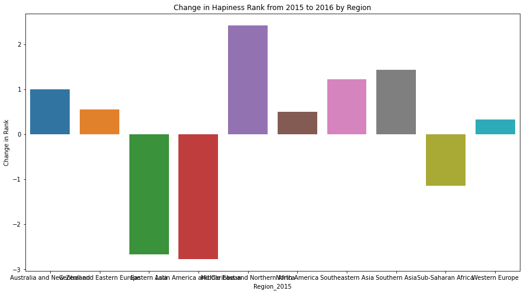

```python
ax = plt.figure(figsize=(15,8));
sns.barplot(data = list2, x = 'Region_2015', y = 'Change in Rank').set_title('Change in Hapiness Rank from 2015 to 2016 by Region');
```

We observe that there is a great difference between Change in happiness Rank. While Sub-Saharan Africa, Eastern Asia and Latin America show a great decline in Rank.

# Correlation Analysis Between Happiness Score and GDP per Capita: Does money bring Happiness?

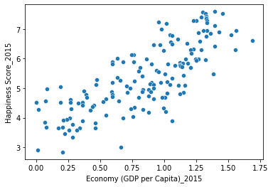

```python
sns.scatterplot(data = df, x = 'Economy (GDP per Capita)_2015', y = 'Happiness Score_2015' );
```

## Shapiro-Wilk Test for testing the Assamption of Normal Distribution

```python
from scipy.stats import shapiro
```

```python
test_statistic, pvalue = shapiro(df["Economy (GDP per Capita)_2015"])
print('Test Statistic = %.4f, p-value = %.4f' % (test_statistic, pvalue))

test_statistic, pvalue = shapiro(df["Happiness Score_2015"])
print('Test Statistic = %.4f, p-value = %.4f' % (test_statistic, pvalue))
```

```
Test Statistic = 0.9650, p-value = 0.0005
Test Statistic = 0.9795, p-value = 0.0188
```

Both variables have failed Shapiro-Wilk Test, therefore, we will not use Pearson Correlation Coefficient but regard Spearman, however lets start with Pearson to see

#### Pearson Correlation Coefficient

```python
df["Happiness Score_2015"].corr(df["Economy (GDP per Capita)_2015"])
```

```
0.7809655268660216
```

#### Spearman Correlation Coefficient

```python
df["Happiness Score_2015"].corr(df["Economy (GDP per Capita)_2015"], method = 'spearman')
```

```
0.7957028014396273
```

### Result: The nonparametric Spearman test tells us that there is a strong correlation between money and happiness

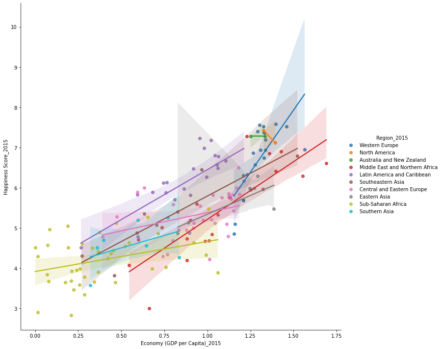

```python
ax = plt.figure(figsize=(15,8));
sns.lmplot(data = df, x = 'Economy (GDP per Capita)_2015', y = 'Happiness Score_2015', hue = 'Region_2015' ,height=10, aspect=1)
```

What is more surprising is that, the lineer model is not declining after a point of Economic saturation. On the contrary, as can be seen, the most sharp increase in Happiness with more money is observed in Western Europe, although it is already one of the most economically rich regions.

However, this plot tells us more. The fact that some countries with close economic figures happiness score is more than others shows that other factors such as freedom also affects happiness score

So although we observed that, lets say, 'money brings happiness', we dont know whether it is the most important determinant of happiness. And now I want to determine the feature importances. I will use the coefficient numbers for determining feature importances

```python
df2015.head()
```

|  | Country | Region_2015 | Happiness Rank_2015 | Happiness Score_2015 | Standard Error_2015 | Economy (GDP per Capita)_2015 | Family_2015 | Health (Life Expectancy)_2015 | Freedom_2015 | Trust (Government Corruption)_2015 | Generosity_2015 | Dystopia Residual_2015 |
| --- | --- | --- | --- | --- | --- | --- | --- | --- | --- | --- | --- | --- |
| 0 | Switzerland | Western Europe | 1 | 7.587 | 0.03411 | 1.39651 | 1.34951 | 0.94143 | 0.66557 | 0.41978 | 0.29678 | 2.51738 |
| 1 | Iceland | Western Europe | 2 | 7.561 | 0.04884 | 1.30232 | 1.40223 | 0.94784 | 0.62877 | 0.14145 | 0.43630 | 2.70201 |
| 2 | Denmark | Western Europe | 3 | 7.527 | 0.03328 | 1.32548 | 1.36058 | 0.87464 | 0.64938 | 0.48357 | 0.34139 | 2.49204 |
| 3 | Norway | Western Europe | 4 | 7.522 | 0.03880 | 1.45900 | 1.33095 | 0.88521 | 0.66973 | 0.36503 | 0.34699 | 2.46531 |
| 4 | Canada | North America | 5 | 7.427 | 0.03553 | 1.32629 | 1.32261 | 0.90563 | 0.63297 | 0.32957 | 0.45811 | 2.45176 |

```python
df2015_ = df2015.iloc[:, [3, 5, 6, 7, 8, 9, 10]]
```

```python
df2015_.head()
```

|  | Happiness Score_2015 | Economy (GDP per Capita)_2015 | Family_2015 | Health (Life Expectancy)_2015 | Freedom_2015 | Trust (Government Corruption)_2015 | Generosity_2015 |
| --- | --- | --- | --- | --- | --- | --- | --- |
| 0 | 7.587 | 1.39651 | 1.34951 | 0.94143 | 0.66557 | 0.41978 | 0.29678 |
| 1 | 7.561 | 1.30232 | 1.40223 | 0.94784 | 0.62877 | 0.14145 | 0.43630 |
| 2 | 7.527 | 1.32548 | 1.36058 | 0.87464 | 0.64938 | 0.48357 | 0.34139 |
| 3 | 7.522 | 1.45900 | 1.33095 | 0.88521 | 0.66973 | 0.36503 | 0.34699 |
| 4 | 7.427 | 1.32629 | 1.32261 | 0.90563 | 0.63297 | 0.32957 | 0.45811 |

```python
from sklearn.model_selection import train_test_split, cross_val_score, cross_val_predict
```

```python
X = df2015_.drop("Happiness Score_2015", axis = 1)
y = df2015_["Happiness Score_2015"]

X_train, X_test, y_train, y_test = train_test_split(X, y, test_size = 0.20, random_state= 42)
```

```python
X_train.shape
```

```
(126, 6)
```

## Statsmodels

```python
import statsmodels.api as sm
```

```python
lm = sm.OLS(y_train, X_train)
```

```python
model = lm.fit()
model.summary()
```

OLS Regression Results

| Dep. Variable: | Happiness Score_2015 | R-squared (uncentered): | 0.983 |
| --- | --- | --- | --- |
| Model: | OLS | Adj. R-squared (uncentered): | 0.982 |
| Method: | Least Squares | F-statistic: | 1168. |
| Date: | Thu, 12 May 2022 | Prob (F-statistic): | 6.72e-104 |
| Time: | 18:28:33 | Log-Likelihood: | -136.48 |
| No. Observations: | 126 | AIC: | 285.0 |
| Df Residuals: | 120 | BIC: | 302.0 |
| Df Model: | 6 |  |  |
| Covariance Type: | nonrobust |  |  |

|  | coef | std err | t | P>\|t\| | [0.025 | 0.975] |
| --- | --- | --- | --- | --- | --- | --- |
| Economy (GDP per Capita)_2015 | 0.4108 | 0.322 | 1.274 | 0.205 | -0.228 | 1.049 |
| Family_2015 | 2.4202 | 0.285 | 8.484 | 0.000 | 1.855 | 2.985 |
| Health (Life Expectancy)_2015 | 1.8708 | 0.450 | 4.156 | 0.000 | 0.980 | 2.762 |
| Freedom_2015 | 2.2321 | 0.544 | 4.105 | 0.000 | 1.156 | 3.309 |
| Trust (Government Corruption)_2015 | 0.5273 | 0.635 | 0.830 | 0.408 | -0.730 | 1.785 |
| Generosity_2015 | 1.2692 | 0.593 | 2.141 | 0.034 | 0.095 | 2.443 |

| Omnibus: | 1.348 | Durbin-Watson: | 1.946 |
| --- | --- | --- | --- |
| Prob(Omnibus): | 0.510 | Jarque-Bera (JB): | 0.921 |
| Skew: | 0.177 | Prob(JB): | 0.631 |
| Kurtosis: | 3.225 | Cond. No. | 18.0 |

Notes:  
[1] R² is computed without centering (uncentered) since the model does not contain a constant.  
[2] Standard Errors assume that the covariance matrix of the errors is correctly specified.

A simple coefficient analysis with statsmodels show us that Economy actually is of the leadt importance for happiness. However, our data is not scaled, therefore it may give us a false result. Furthermore, for a more robust result, I will also add 2016, and 2017 data to our coefficient analysis than build the model.

```python
df2015 = pd.read_csv('2015.csv')
```

```python
df2015.head()
```

|  | Country | Region | Happiness Rank | Happiness Score | Standard Error | Economy (GDP per Capita) | Family | Health (Life Expectancy) | Freedom | Trust (Government Corruption) | Generosity | Dystopia Residual |
| --- | --- | --- | --- | --- | --- | --- | --- | --- | --- | --- | --- | --- |
| 0 | Switzerland | Western Europe | 1 | 7.587 | 0.03411 | 1.39651 | 1.34951 | 0.94143 | 0.66557 | 0.41978 | 0.29678 | 2.51738 |
| 1 | Iceland | Western Europe | 2 | 7.561 | 0.04884 | 1.30232 | 1.40223 | 0.94784 | 0.62877 | 0.14145 | 0.43630 | 2.70201 |
| 2 | Denmark | Western Europe | 3 | 7.527 | 0.03328 | 1.32548 | 1.36058 | 0.87464 | 0.64938 | 0.48357 | 0.34139 | 2.49204 |
| 3 | Norway | Western Europe | 4 | 7.522 | 0.03880 | 1.45900 | 1.33095 | 0.88521 | 0.66973 | 0.36503 | 0.34699 | 2.46531 |
| 4 | Canada | North America | 5 | 7.427 | 0.03553 | 1.32629 | 1.32261 | 0.90563 | 0.63297 | 0.32957 | 0.45811 | 2.45176 |

```python
df2016 = pd.read_csv('2016.csv')
```

```python
df2019 = pd.read_csv('2019.csv')
```

```python
df2019.head()
```

|  | Overall rank | Country or region | Score | GDP per capita | Social support | Healthy life expectancy | Freedom to make life choices | Generosity | Perceptions of corruption |
| --- | --- | --- | --- | --- | --- | --- | --- | --- | --- |
| 0 | 1 | Finland | 7.769 | 1.340 | 1.587 | 0.986 | 0.596 | 0.153 | 0.393 |
| 1 | 2 | Denmark | 7.600 | 1.383 | 1.573 | 0.996 | 0.592 | 0.252 | 0.410 |
| 2 | 3 | Norway | 7.554 | 1.488 | 1.582 | 1.028 | 0.603 | 0.271 | 0.341 |
| 3 | 4 | Iceland | 7.494 | 1.380 | 1.624 | 1.026 | 0.591 | 0.354 | 0.118 |
| 4 | 5 | Netherlands | 7.488 | 1.396 | 1.522 | 0.999 | 0.557 | 0.322 | 0.298 |

```python
df2018 = pd.read_csv('2018.csv')
```

```python
df2018.head()
```

|  | Overall rank | Country or region | Score | GDP per capita | Social support | Healthy life expectancy | Freedom to make life choices | Generosity | Perceptions of corruption |
| --- | --- | --- | --- | --- | --- | --- | --- | --- | --- |
| 0 | 1 | Finland | 7.632 | 1.305 | 1.592 | 0.874 | 0.681 | 0.202 | 0.393 |
| 1 | 2 | Norway | 7.594 | 1.456 | 1.582 | 0.861 | 0.686 | 0.286 | 0.340 |
| 2 | 3 | Denmark | 7.555 | 1.351 | 1.590 | 0.868 | 0.683 | 0.284 | 0.408 |
| 3 | 4 | Iceland | 7.495 | 1.343 | 1.644 | 0.914 | 0.677 | 0.353 | 0.138 |
| 4 | 5 | Switzerland | 7.487 | 1.420 | 1.549 | 0.927 | 0.660 | 0.256 | 0.357 |

```python
df2017 = pd.read_csv('2017.csv')
```

```python
df2017.head()
```

|  | Country | Happiness.Rank | Happiness.Score | Whisker.high | Whisker.low | Economy..GDP.per.Capita. | Family | Health..Life.Expectancy. | Freedom | Generosity | Trust..Government.Corruption. | Dystopia.Residual |
| --- | --- | --- | --- | --- | --- | --- | --- | --- | --- | --- | --- | --- |
| 0 | Norway | 1 | 7.537 | 7.594445 | 7.479556 | 1.616463 | 1.533524 | 0.796667 | 0.635423 | 0.362012 | 0.315964 | 2.277027 |
| 1 | Denmark | 2 | 7.522 | 7.581728 | 7.462272 | 1.482383 | 1.551122 | 0.792566 | 0.626007 | 0.355280 | 0.400770 | 2.313707 |
| 2 | Iceland | 3 | 7.504 | 7.622030 | 7.385970 | 1.480633 | 1.610574 | 0.833552 | 0.627163 | 0.475540 | 0.153527 | 2.322715 |
| 3 | Switzerland | 4 | 7.494 | 7.561772 | 7.426227 | 1.564980 | 1.516912 | 0.858131 | 0.620071 | 0.290549 | 0.367007 | 2.276716 |
| 4 | Finland | 5 | 7.469 | 7.527542 | 7.410458 | 1.443572 | 1.540247 | 0.809158 | 0.617951 | 0.245483 | 0.382612 | 2.430182 |

As some indexes are different in 2019 and 2018, I will use 2015, 2016 and 2017 data to get the feature importances for Happiness Score.

```python
df2015.columns
```

```
Index(['Country', 'Region', 'Happiness Rank', 'Happiness Score',
       'Standard Error', 'Economy (GDP per Capita)', 'Family',
       'Health (Life Expectancy)', 'Freedom', 'Trust (Government Corruption)',
       'Generosity', 'Dystopia Residual'],
      dtype='object')
```

```python
df2015.shape
```

```
(158, 12)
```

```python
df5 = df2015.iloc[0:158, [0, 1, 2, 3, 5, 6, 7, 8, 9, 10]]
```

```python
df5
```

|  | Country | Region | Happiness Rank | Happiness Score | Economy (GDP per Capita) | Family | Health (Life Expectancy) | Freedom | Trust (Government Corruption) | Generosity |
| --- | --- | --- | --- | --- | --- | --- | --- | --- | --- | --- |
| 0 | Switzerland | Western Europe | 1 | 7.587 | 1.39651 | 1.34951 | 0.94143 | 0.66557 | 0.41978 | 0.29678 |
| 1 | Iceland | Western Europe | 2 | 7.561 | 1.30232 | 1.40223 | 0.94784 | 0.62877 | 0.14145 | 0.43630 |
| 2 | Denmark | Western Europe | 3 | 7.527 | 1.32548 | 1.36058 | 0.87464 | 0.64938 | 0.48357 | 0.34139 |
| 3 | Norway | Western Europe | 4 | 7.522 | 1.45900 | 1.33095 | 0.88521 | 0.66973 | 0.36503 | 0.34699 |
| 4 | Canada | North America | 5 | 7.427 | 1.32629 | 1.32261 | 0.90563 | 0.63297 | 0.32957 | 0.45811 |
| ... | ... | ... | ... | ... | ... | ... | ... | ... | ... | ... |
| 153 | Rwanda | Sub-Saharan Africa | 154 | 3.465 | 0.22208 | 0.77370 | 0.42864 | 0.59201 | 0.55191 | 0.22628 |
| 154 | Benin | Sub-Saharan Africa | 155 | 3.340 | 0.28665 | 0.35386 | 0.31910 | 0.48450 | 0.08010 | 0.18260 |
| 155 | Syria | Middle East and Northern Africa | 156 | 3.006 | 0.66320 | 0.47489 | 0.72193 | 0.15684 | 0.18906 | 0.47179 |
| 156 | Burundi | Sub-Saharan Africa | 157 | 2.905 | 0.01530 | 0.41587 | 0.22396 | 0.11850 | 0.10062 | 0.19727 |
| 157 | Togo | Sub-Saharan Africa | 158 | 2.839 | 0.20868 | 0.13995 | 0.28443 | 0.36453 | 0.10731 | 0.16681 |

158 rows × 10 columns

```python
df2016.columns
```

```
Index(['Country', 'Region', 'Happiness Rank', 'Happiness Score',
       'Lower Confidence Interval', 'Upper Confidence Interval',
       'Economy (GDP per Capita)', 'Family', 'Health (Life Expectancy)',
       'Freedom', 'Trust (Government Corruption)', 'Generosity',
       'Dystopia Residual'],
      dtype='object')
```

```python
df2016.shape
```

```
(157, 13)
```

```python
df6 = df2016.iloc[0:158, [0, 1, 2, 3,6, 7,8,9,10, 11]]
```

```python
df6
```

|  | Country | Region | Happiness Rank | Happiness Score | Economy (GDP per Capita) | Family | Health (Life Expectancy) | Freedom | Trust (Government Corruption) | Generosity |
| --- | --- | --- | --- | --- | --- | --- | --- | --- | --- | --- |
| 0 | Denmark | Western Europe | 1 | 7.526 | 1.44178 | 1.16374 | 0.79504 | 0.57941 | 0.44453 | 0.36171 |
| 1 | Switzerland | Western Europe | 2 | 7.509 | 1.52733 | 1.14524 | 0.86303 | 0.58557 | 0.41203 | 0.28083 |
| 2 | Iceland | Western Europe | 3 | 7.501 | 1.42666 | 1.18326 | 0.86733 | 0.56624 | 0.14975 | 0.47678 |
| 3 | Norway | Western Europe | 4 | 7.498 | 1.57744 | 1.12690 | 0.79579 | 0.59609 | 0.35776 | 0.37895 |
| 4 | Finland | Western Europe | 5 | 7.413 | 1.40598 | 1.13464 | 0.81091 | 0.57104 | 0.41004 | 0.25492 |
| ... | ... | ... | ... | ... | ... | ... | ... | ... | ... | ... |
| 152 | Benin | Sub-Saharan Africa | 153 | 3.484 | 0.39499 | 0.10419 | 0.21028 | 0.39747 | 0.06681 | 0.20180 |
| 153 | Afghanistan | Southern Asia | 154 | 3.360 | 0.38227 | 0.11037 | 0.17344 | 0.16430 | 0.07112 | 0.31268 |
| 154 | Togo | Sub-Saharan Africa | 155 | 3.303 | 0.28123 | 0.00000 | 0.24811 | 0.34678 | 0.11587 | 0.17517 |
| 155 | Syria | Middle East and Northern Africa | 156 | 3.069 | 0.74719 | 0.14866 | 0.62994 | 0.06912 | 0.17233 | 0.48397 |
| 156 | Burundi | Sub-Saharan Africa | 157 | 2.905 | 0.06831 | 0.23442 | 0.15747 | 0.04320 | 0.09419 | 0.20290 |

157 rows × 10 columns

```python
df2017.columns
```

```
Index(['Country', 'Happiness.Rank', 'Happiness.Score', 'Whisker.high',
       'Whisker.low', 'Economy..GDP.per.Capita.', 'Family',
       'Health..Life.Expectancy.', 'Freedom', 'Generosity',
       'Trust..Government.Corruption.', 'Dystopia.Residual'],
      dtype='object')
```

```python
df7 = df2017.iloc[0:158, [0, 1, 2, 5, 6, 7, 8, 9, 10]]
```

```python
df7
```

|  | Country | Happiness.Rank | Happiness.Score | Economy..GDP.per.Capita. | Family | Health..Life.Expectancy. | Freedom | Generosity | Trust..Government.Corruption. |
| --- | --- | --- | --- | --- | --- | --- | --- | --- | --- |
| 0 | Norway | 1 | 7.537 | 1.616463 | 1.533524 | 0.796667 | 0.635423 | 0.362012 | 0.315964 |
| 1 | Denmark | 2 | 7.522 | 1.482383 | 1.551122 | 0.792566 | 0.626007 | 0.355280 | 0.400770 |
| 2 | Iceland | 3 | 7.504 | 1.480633 | 1.610574 | 0.833552 | 0.627163 | 0.475540 | 0.153527 |
| 3 | Switzerland | 4 | 7.494 | 1.564980 | 1.516912 | 0.858131 | 0.620071 | 0.290549 | 0.367007 |
| 4 | Finland | 5 | 7.469 | 1.443572 | 1.540247 | 0.809158 | 0.617951 | 0.245483 | 0.382612 |
| ... | ... | ... | ... | ... | ... | ... | ... | ... | ... |
| 150 | Rwanda | 151 | 3.471 | 0.368746 | 0.945707 | 0.326425 | 0.581844 | 0.252756 | 0.455220 |
| 151 | Syria | 152 | 3.462 | 0.777153 | 0.396103 | 0.500533 | 0.081539 | 0.493664 | 0.151347 |
| 152 | Tanzania | 153 | 3.349 | 0.511136 | 1.041990 | 0.364509 | 0.390018 | 0.354256 | 0.066035 |
| 153 | Burundi | 154 | 2.905 | 0.091623 | 0.629794 | 0.151611 | 0.059901 | 0.204435 | 0.084148 |
| 154 | Central African Republic | 155 | 2.693 | 0.000000 | 0.000000 | 0.018773 | 0.270842 | 0.280876 | 0.056565 |

155 rows × 9 columns

df2017 lacks the region info. Lets look it up from 2016 data.

```python
regions = df2016.iloc[0:158, [0, 1]]
```

```python
df7_ = df7.merge(regions, on='Country', how = 'left')
```

```python
df7_
```

|  | Country | Happiness.Rank | Happiness.Score | Economy..GDP.per.Capita. | Family | Health..Life.Expectancy. | Freedom | Generosity | Trust..Government.Corruption. | Region |
| --- | --- | --- | --- | --- | --- | --- | --- | --- | --- | --- |
| 0 | Norway | 1 | 7.537 | 1.616463 | 1.533524 | 0.796667 | 0.635423 | 0.362012 | 0.315964 | Western Europe |
| 1 | Denmark | 2 | 7.522 | 1.482383 | 1.551122 | 0.792566 | 0.626007 | 0.355280 | 0.400770 | Western Europe |
| 2 | Iceland | 3 | 7.504 | 1.480633 | 1.610574 | 0.833552 | 0.627163 | 0.475540 | 0.153527 | Western Europe |
| 3 | Switzerland | 4 | 7.494 | 1.564980 | 1.516912 | 0.858131 | 0.620071 | 0.290549 | 0.367007 | Western Europe |
| 4 | Finland | 5 | 7.469 | 1.443572 | 1.540247 | 0.809158 | 0.617951 | 0.245483 | 0.382612 | Western Europe |
| ... | ... | ... | ... | ... | ... | ... | ... | ... | ... | ... |
| 150 | Rwanda | 151 | 3.471 | 0.368746 | 0.945707 | 0.326425 | 0.581844 | 0.252756 | 0.455220 | Sub-Saharan Africa |
| 151 | Syria | 152 | 3.462 | 0.777153 | 0.396103 | 0.500533 | 0.081539 | 0.493664 | 0.151347 | Middle East and Northern Africa |
| 152 | Tanzania | 153 | 3.349 | 0.511136 | 1.041990 | 0.364509 | 0.390018 | 0.354256 | 0.066035 | Sub-Saharan Africa |
| 153 | Burundi | 154 | 2.905 | 0.091623 | 0.629794 | 0.151611 | 0.059901 | 0.204435 | 0.084148 | Sub-Saharan Africa |
| 154 | Central African Republic | 155 | 2.693 | 0.000000 | 0.000000 | 0.018773 | 0.270842 | 0.280876 | 0.056565 | NaN |

155 rows × 10 columns

```python
df7_.isna().sum()
```

```
Country                          0
Happiness.Rank                   0
Happiness.Score                  0
Economy..GDP.per.Capita.         0
Family                           0
Health..Life.Expectancy.         0
Freedom                          0
Generosity                       0
Trust..Government.Corruption.    0
Region                           5
dtype: int64
```

### Changing the Column Order for Rbind

```python
df5.columns
```

```
Index(['Country', 'Region', 'Happiness Rank', 'Happiness Score',
       'Economy (GDP per Capita)', 'Family', 'Health (Life Expectancy)',
       'Freedom', 'Trust (Government Corruption)', 'Generosity'],
      dtype='object')
```

```python
df7.columns
```

```
Index(['Country', 'Happiness.Rank', 'Happiness.Score',
       'Economy..GDP.per.Capita.', 'Family', 'Health..Life.Expectancy.',
       'Freedom', 'Generosity', 'Trust..Government.Corruption.'],
      dtype='object')
```

```python
df7.rename(columns = {'Happiness.Rank':'Happiness Rank', 'Happiness.Score':'Happiness Score', 'Economy..GDP.per.Capita.' : 'Economy (GDP per Capita)', 'Health..Life.Expectancy.' : 'Health (Life Expectancy)', 'Trust..Government.Corruption.': 'Trust (Government Corruption)'}, inplace = True)
```

```python
df7 = df7.merge(regions, on='Country', how = 'left')
```

```python
df7.columns
```

```
Index(['Country', 'Happiness Rank', 'Happiness Score',
       'Economy (GDP per Capita)', 'Family', 'Health (Life Expectancy)',
       'Freedom', 'Generosity', 'Trust (Government Corruption)', 'Region'],
      dtype='object')
```

```python
df6.columns
```

```
Index(['Country', 'Region', 'Happiness Rank', 'Happiness Score',
       'Economy (GDP per Capita)', 'Family', 'Health (Life Expectancy)',
       'Freedom', 'Trust (Government Corruption)', 'Generosity'],
      dtype='object')
```

```python
df6 = df6[['Country', 'Region', 'Happiness Rank', 'Happiness Score',
       'Economy (GDP per Capita)', 'Family', 'Health (Life Expectancy)',
       'Freedom', 'Trust (Government Corruption)', 'Generosity']]
```

```python
df6.head()
```

|  | Country | Region | Happiness Rank | Happiness Score | Economy (GDP per Capita) | Family | Health (Life Expectancy) | Freedom | Trust (Government Corruption) | Generosity |
| --- | --- | --- | --- | --- | --- | --- | --- | --- | --- | --- |
| 0 | Denmark | Western Europe | 1 | 7.526 | 1.44178 | 1.16374 | 0.79504 | 0.57941 | 0.44453 | 0.36171 |
| 1 | Switzerland | Western Europe | 2 | 7.509 | 1.52733 | 1.14524 | 0.86303 | 0.58557 | 0.41203 | 0.28083 |
| 2 | Iceland | Western Europe | 3 | 7.501 | 1.42666 | 1.18326 | 0.86733 | 0.56624 | 0.14975 | 0.47678 |
| 3 | Norway | Western Europe | 4 | 7.498 | 1.57744 | 1.12690 | 0.79579 | 0.59609 | 0.35776 | 0.37895 |
| 4 | Finland | Western Europe | 5 | 7.413 | 1.40598 | 1.13464 | 0.81091 | 0.57104 | 0.41004 | 0.25492 |

```python
df7 = df7[['Country', 'Region', 'Happiness Rank', 'Happiness Score',
       'Economy (GDP per Capita)', 'Family', 'Health (Life Expectancy)',
       'Freedom', 'Trust (Government Corruption)', 'Generosity']]
```

```python
df7.head()
```

|  | Country | Region | Happiness Rank | Happiness Score | Economy (GDP per Capita) | Family | Health (Life Expectancy) | Freedom | Trust (Government Corruption) | Generosity |
| --- | --- | --- | --- | --- | --- | --- | --- | --- | --- | --- |
| 0 | Norway | Western Europe | 1 | 7.537 | 1.616463 | 1.533524 | 0.796667 | 0.635423 | 0.315964 | 0.362012 |
| 1 | Denmark | Western Europe | 2 | 7.522 | 1.482383 | 1.551122 | 0.792566 | 0.626007 | 0.400770 | 0.355280 |
| 2 | Iceland | Western Europe | 3 | 7.504 | 1.480633 | 1.610574 | 0.833552 | 0.627163 | 0.153527 | 0.475540 |
| 3 | Switzerland | Western Europe | 4 | 7.494 | 1.564980 | 1.516912 | 0.858131 | 0.620071 | 0.367007 | 0.290549 |
| 4 | Finland | Western Europe | 5 | 7.469 | 1.443572 | 1.540247 | 0.809158 | 0.617951 | 0.382612 | 0.245483 |

```python
df5.shape
```

```
(158, 10)
```

```python
df6.shape
```

```
(157, 10)
```

```python
df7.shape
```

```
(155, 10)
```

```python
df2 = pd.concat([df5, df6, df7], ignore_index=True)
```

```python
df2.shape
```

```
(470, 10)
```

```python
df2.describe().T
```

|  | count | mean | std | min | 25% | 50% | 75% | max |
| --- | --- | --- | --- | --- | --- | --- | --- | --- |
| Happiness Rank | 470.0 | 78.829787 | 45.281408 | 1.000 | 40.000000 | 79.000000 | 118.000000 | 158.000000 |
| Happiness Score | 470.0 | 5.370728 | 1.136998 | 2.693 | 4.509000 | 5.282500 | 6.233750 | 7.587000 |
| Economy (GDP per Capita) | 470.0 | 0.927830 | 0.415584 | 0.000 | 0.605292 | 0.995439 | 1.252443 | 1.870766 |
| Family | 470.0 | 0.990347 | 0.318707 | 0.000 | 0.793000 | 1.025665 | 1.228745 | 1.610574 |
| Health (Life Expectancy) | 470.0 | 0.579968 | 0.240161 | 0.000 | 0.402301 | 0.630053 | 0.768298 | 1.025250 |
| Freedom | 470.0 | 0.402828 | 0.150356 | 0.000 | 0.297615 | 0.418347 | 0.516850 | 0.669730 |
| Trust (Government Corruption) | 470.0 | 0.134790 | 0.111313 | 0.000 | 0.059777 | 0.099502 | 0.173161 | 0.551910 |
| Generosity | 470.0 | 0.242241 | 0.131543 | 0.000 | 0.152831 | 0.223140 | 0.315824 | 0.838075 |

```python
df2.corr()
```

|  | Happiness Rank | Happiness Score | Economy (GDP per Capita) | Family | Health (Life Expectancy) | Freedom | Trust (Government Corruption) | Generosity |
| --- | --- | --- | --- | --- | --- | --- | --- | --- |
| Happiness Rank | 1.000000 | -0.993268 | -0.790551 | -0.637627 | -0.750146 | -0.547627 | -0.384371 | -0.146162 |
| Happiness Score | -0.993268 | 1.000000 | 0.785450 | 0.636532 | 0.748040 | 0.560353 | 0.406340 | 0.163562 |
| Economy (GDP per Capita) | -0.790551 | 0.785450 | 1.000000 | 0.585449 | 0.792224 | 0.344962 | 0.301935 | -0.014173 |
| Family | -0.637627 | 0.636532 | 0.585449 | 1.000000 | 0.486383 | 0.425377 | 0.158605 | 0.071775 |
| Health (Life Expectancy) | -0.750146 | 0.748040 | 0.792224 | 0.486383 | 1.000000 | 0.359566 | 0.262932 | 0.077326 |
| Freedom | -0.547627 | 0.560353 | 0.344962 | 0.425377 | 0.359566 | 1.000000 | 0.490405 | 0.343389 |
| Trust (Government Corruption) | -0.384371 | 0.406340 | 0.301935 | 0.158605 | 0.262932 | 0.490405 | 1.000000 | 0.287414 |
| Generosity | -0.146162 | 0.163562 | -0.014173 | 0.071775 | 0.077326 | 0.343389 | 0.287414 | 1.000000 |

```python
df2.isnull().sum()
```

```
Country                          0
Region                           5
Happiness Rank                   0
Happiness Score                  0
Economy (GDP per Capita)         0
Family                           0
Health (Life Expectancy)         0
Freedom                          0
Trust (Government Corruption)    0
Generosity                       0
dtype: int64
```

Taking out the Country, Region and Happiness Rank for Machine Learning model

```python
df3 = df2.drop(['Happiness Rank', 'Country', 'Region'], axis=1)
```

```python
df3.head()
```

|  | Happiness Score | Economy (GDP per Capita) | Family | Health (Life Expectancy) | Freedom | Trust (Government Corruption) | Generosity |
| --- | --- | --- | --- | --- | --- | --- | --- |
| 0 | 7.587 | 1.39651 | 1.34951 | 0.94143 | 0.66557 | 0.41978 | 0.29678 |
| 1 | 7.561 | 1.30232 | 1.40223 | 0.94784 | 0.62877 | 0.14145 | 0.43630 |
| 2 | 7.527 | 1.32548 | 1.36058 | 0.87464 | 0.64938 | 0.48357 | 0.34139 |
| 3 | 7.522 | 1.45900 | 1.33095 | 0.88521 | 0.66973 | 0.36503 | 0.34699 |
| 4 | 7.427 | 1.32629 | 1.32261 | 0.90563 | 0.63297 | 0.32957 | 0.45811 |

```python
df3.columns
```

```
Index(['Happiness Score', 'Economy (GDP per Capita)', 'Family',
       'Health (Life Expectancy)', 'Freedom', 'Trust (Government Corruption)',
       'Generosity'],
      dtype='object')
```

```python
df3.shape
```

```
(470, 7)
```

### Scaling the Data for Getting Coefficients as Feature Importances

```python
from sklearn.preprocessing import MinMaxScaler
```

```python
MinMax = MinMaxScaler()
```

```python
MinMax.fit(df3)
```

```
MinMaxScaler()
```

```python
df3_scaled = MinMax.transform(df3)
```

```python
df3_scaled_ = pd.DataFrame(df3_scaled)
```

```python
df3_scaled_.head()
```

|  | 0 | 1 | 2 | 3 | 4 | 5 | 6 |
| --- | --- | --- | --- | --- | --- | --- | --- |
| 0 | 1.000000 | 0.746491 | 0.837906 | 0.918244 | 0.993789 | 0.760595 | 0.354121 |
| 1 | 0.994687 | 0.696143 | 0.870640 | 0.924496 | 0.938841 | 0.256292 | 0.520598 |
| 2 | 0.987740 | 0.708523 | 0.844780 | 0.853099 | 0.969615 | 0.876175 | 0.407350 |
| 3 | 0.986718 | 0.779895 | 0.826382 | 0.863409 | 1.000000 | 0.661394 | 0.414032 |
| 4 | 0.967307 | 0.708956 | 0.821204 | 0.883326 | 0.945112 | 0.597144 | 0.546622 |

```python
y = df3_scaled_[0]
X = df3_scaled_.drop(0, axis = 1)
```

```python
from sklearn.model_selection import train_test_split, cross_val_score, cross_val_predict
```

```python
X_train, X_test, y_train, y_test = train_test_split(X, y, test_size = 0.20, random_state= 42)
```

```python
X_train.shape
```

```
(376, 6)
```

```python
X_train.shape
```

```
(376, 6)
```

```python
y_train.head()
```

```
414    0.462199
305    0.204740
22     0.841234
307    0.189824
46     0.672456
Name: 0, dtype: float64
```

### Statsmodels Again

```python
import statsmodels.api as sm
```

```python
lm = sm.OLS(y_train, X_train)
```

```python
model1 = lm.fit()
model1.summary()
```

OLS Regression Results

| Dep. Variable: | y | R-squared (uncentered): | 0.964 |
| --- | --- | --- | --- |
| Model: | OLS | Adj. R-squared (uncentered): | 0.964 |
| Method: | Least Squares | F-statistic: | 1672. |
| Date: | Mon, 16 May 2022 | Prob (F-statistic): | 1.38e-264 |
| Time: | 17:49:52 | Log-Likelihood: | 281.62 |
| No. Observations: | 376 | AIC: | -551.2 |
| Df Residuals: | 370 | BIC: | -527.7 |
| Df Model: | 6 |  |  |
| Covariance Type: | nonrobust |  |  |

|  | coef | std err | t | P>\|t\| | [0.025 | 0.975] |
| --- | --- | --- | --- | --- | --- | --- |
| 1 | 0.3703 | 0.049 | 7.507 | 0.000 | 0.273 | 0.467 |
| 2 | 0.1561 | 0.036 | 4.295 | 0.000 | 0.085 | 0.228 |
| 3 | 0.2324 | 0.042 | 5.548 | 0.000 | 0.150 | 0.315 |
| 4 | 0.1855 | 0.035 | 5.314 | 0.000 | 0.117 | 0.254 |
| 5 | 0.1176 | 0.036 | 3.293 | 0.001 | 0.047 | 0.188 |
| 6 | 0.0238 | 0.039 | 0.603 | 0.547 | -0.054 | 0.101 |

| Omnibus: | 1.276 | Durbin-Watson: | 1.880 |
| --- | --- | --- | --- |
| Prob(Omnibus): | 0.528 | Jarque-Bera (JB): | 1.354 |
| Skew: | -0.134 | Prob(JB): | 0.508 |
| Kurtosis: | 2.881 | Cond. No. | 13.5 |

Notes:  
[1] R² is computed without centering (uncentered) since the model does not contain a constant.  
[2] Standard Errors assume that the covariance matrix of the errors is correctly specified.

**The P Value of generosity shows us that the correlation between it and Happiness Score seems to be occured by chance, therefore it will not be considered in the feature impotances anymore**

```python
model1.summary().tables[1]
```

|  | coef | std err | t | P>\|t\| | [0.025 | 0.975] |
| --- | --- | --- | --- | --- | --- | --- |
| 1 | 0.3703 | 0.049 | 7.507 | 0.000 | 0.273 | 0.467 |
| 2 | 0.1561 | 0.036 | 4.295 | 0.000 | 0.085 | 0.228 |
| 3 | 0.2324 | 0.042 | 5.548 | 0.000 | 0.150 | 0.315 |
| 4 | 0.1855 | 0.035 | 5.314 | 0.000 | 0.117 | 0.254 |
| 5 | 0.1176 | 0.036 | 3.293 | 0.001 | 0.047 | 0.188 |
| 6 | 0.0238 | 0.039 | 0.603 | 0.547 | -0.054 | 0.101 |

### Scikit-Learn Model

```python
from sklearn.linear_model import LinearRegression
```

```python
lm = LinearRegression()
model = lm.fit(X_train, y_train)
```

```python
model.coef_
```

```
array([0.35552587, 0.22378312, 0.269069  , 0.21434566, 0.10699098,
       0.0735547 ])
```

**We will proceed with Statsmodel coeeficients as feature importances**

```python
print(model1.params)
```

```
1    0.370318
2    0.156062
3    0.232418
4    0.185454
5    0.117644
6    0.023753
dtype: float64
```

```python
params = pd.DataFrame(model1.params)
```

```python
params
```

|  | 0 |
| --- | --- |
| 1 | 0.370318 |
| 2 | 0.156062 |
| 3 | 0.232418 |
| 4 | 0.185454 |
| 5 | 0.117644 |
| 6 | 0.023753 |

```python
params = params.iloc[0:5, [0]]
```

```python
params
```

|  | 0 |
| --- | --- |
| 1 | 0.370318 |
| 2 | 0.156062 |
| 3 | 0.232418 |
| 4 | 0.185454 |
| 5 | 0.117644 |

```python
params[0] = params[0].astype('float64')
```

```python
params.dtypes
```

```
0    float64
dtype: object
```

```python
params = params.reset_index(drop=True)
```

```python
params
```

|  | 0 |
| --- | --- |
| 0 | 0.370318 |
| 1 | 0.156062 |
| 2 | 0.232418 |
| 3 | 0.185454 |
| 4 | 0.117644 |

```python
features = 'Economy (GDP per Capita)', 'Family', 'Health (Life Expectancy)', 'Freedom', 'Trust (Government Corruption)'
```

```python
features = pd.DataFrame(features)
```

```python
features
```

|  | 0 |
| --- | --- |
| 0 | Economy (GDP per Capita) |
| 1 | Family |
| 2 | Health (Life Expectancy) |
| 3 | Freedom |
| 4 | Trust (Government Corruption) |

```python
feature_importances = pd.concat([params, features], ignore_index=True, axis = 1)
```

```python
feature_importances
```

|  | 0 | 1 |
| --- | --- | --- |
| 0 | 0.370318 | Economy (GDP per Capita) |
| 1 | 0.156062 | Family |
| 2 | 0.232418 | Health (Life Expectancy) |
| 3 | 0.185454 | Freedom |
| 4 | 0.117644 | Trust (Government Corruption) |

```python
feature_importances.rename(columns = {0:'Score', 1:'Feature Importance'}, inplace = True)
```

```python
feature_importances
```

|  | Score | Feature Importance |
| --- | --- | --- |
| 0 | 0.370318 | Economy (GDP per Capita) |
| 1 | 0.156062 | Family |
| 2 | 0.232418 | Health (Life Expectancy) |
| 3 | 0.185454 | Freedom |
| 4 | 0.117644 | Trust (Government Corruption) |

```python
feature_importances.dtypes
```

```
Score                 float64
Feature Importance     object
dtype: object
```

```python
feature_importances.shape
```

```
(5, 2)
```

```python
import seaborn as sns
```

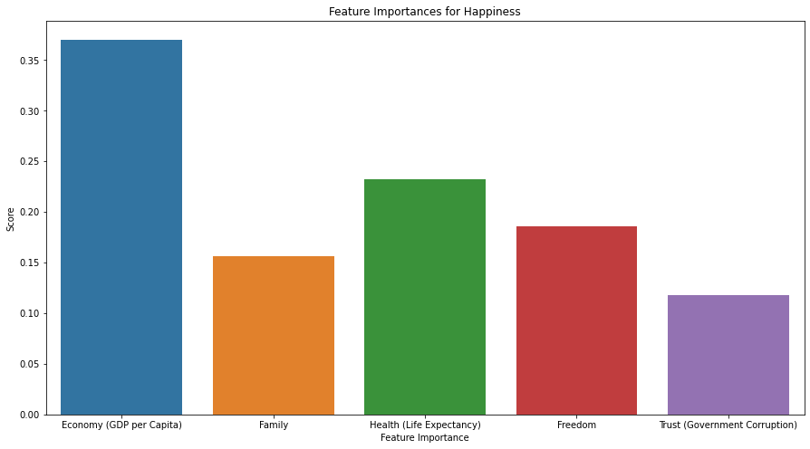

```python
ax = plt.figure(figsize=(15,8));
sns.barplot(data = feature_importances, x = feature_importances['Feature Importance'], y = feature_importances['Score']).set_title('Feature Importances for Happiness');
```

## World Map Visualization

```python
df2019 = pd.read_csv('2019.csv')
```

```python
df2019.head()
```

|  | Overall rank | Country or region | Score | GDP per capita | Social support | Healthy life expectancy | Freedom to make life choices | Generosity | Perceptions of corruption |
| --- | --- | --- | --- | --- | --- | --- | --- | --- | --- |
| 0 | 1 | Finland | 7.769 | 1.340 | 1.587 | 0.986 | 0.596 | 0.153 | 0.393 |
| 1 | 2 | Denmark | 7.600 | 1.383 | 1.573 | 0.996 | 0.592 | 0.252 | 0.410 |
| 2 | 3 | Norway | 7.554 | 1.488 | 1.582 | 1.028 | 0.603 | 0.271 | 0.341 |
| 3 | 4 | Iceland | 7.494 | 1.380 | 1.624 | 1.026 | 0.591 | 0.354 | 0.118 |
| 4 | 5 | Netherlands | 7.488 | 1.396 | 1.522 | 0.999 | 0.557 | 0.322 | 0.298 |

```python
df2019.shape
```

```
(156, 9)
```

```python
df2019.isnull().any()
```

```
Overall rank                    False
Country or region               False
Score                           False
GDP per capita                  False
Social support                  False
Healthy life expectancy         False
Freedom to make life choices    False
Generosity                      False
Perceptions of corruption       False
dtype: bool
```

Data lacks iso3 codes, lets get it

```python
df2019.rename(columns={"Country or region": "Country"}, inplace = True)
```

```python
iso3codes = pd.read_excel('UNSD.xlsx')
```

```python
iso3codes.head()
```

|  | Global Code | Global Name | Region Code | Region Name | Sub-region Code | Sub-region Name | Intermediate Region Code | Intermediate Region Name | Country or Area | M49 Code | ISO-alpha2 Code | ISO-alpha3 Code |
| --- | --- | --- | --- | --- | --- | --- | --- | --- | --- | --- | --- | --- |
| 0 | 1 | World | 2.0 | Africa | 15.0 | Northern Africa | NaN | NaN | Algeria | 12 | DZ | DZA |
| 1 | 1 | World | 2.0 | Africa | 15.0 | Northern Africa | NaN | NaN | Egypt | 818 | EG | EGY |
| 2 | 1 | World | 2.0 | Africa | 15.0 | Northern Africa | NaN | NaN | Libya | 434 | LY | LBY |
| 3 | 1 | World | 2.0 | Africa | 15.0 | Northern Africa | NaN | NaN | Morocco | 504 | MA | MAR |
| 4 | 1 | World | 2.0 | Africa | 15.0 | Northern Africa | NaN | NaN | Sudan | 729 | SD | SDN |

```python
isocode = pd.DataFrame({'Country' : []})
```

```python
isocode['Country'] = iso3codes['Country or Area']
isocode['Code'] = iso3codes['ISO-alpha3 Code']
```

```python
isocode.head()
```

|  | Country | Code |
| --- | --- | --- |
| 0 | Algeria | DZA |
| 1 | Egypt | EGY |
| 2 | Libya | LBY |
| 3 | Morocco | MAR |
| 4 | Sudan | SDN |

```python
isocode.shape
```

```
(249, 2)
```

```python
df2019.head()
```

|  | Overall rank | Country | Score | GDP per capita | Social support | Healthy life expectancy | Freedom to make life choices | Generosity | Perceptions of corruption |
| --- | --- | --- | --- | --- | --- | --- | --- | --- | --- |
| 0 | 1 | Finland | 7.769 | 1.340 | 1.587 | 0.986 | 0.596 | 0.153 | 0.393 |
| 1 | 2 | Denmark | 7.600 | 1.383 | 1.573 | 0.996 | 0.592 | 0.252 | 0.410 |
| 2 | 3 | Norway | 7.554 | 1.488 | 1.582 | 1.028 | 0.603 | 0.271 | 0.341 |
| 3 | 4 | Iceland | 7.494 | 1.380 | 1.624 | 1.026 | 0.591 | 0.354 | 0.118 |
| 4 | 5 | Netherlands | 7.488 | 1.396 | 1.522 | 0.999 | 0.557 | 0.322 | 0.298 |

```python
df19 = df2019.merge(isocode, on='Country', how = 'left')
```

```python
df19.head()
```

|  | Overall rank | Country | Score | GDP per capita | Social support | Healthy life expectancy | Freedom to make life choices | Generosity | Perceptions of corruption | Code |
| --- | --- | --- | --- | --- | --- | --- | --- | --- | --- | --- |
| 0 | 1 | Finland | 7.769 | 1.340 | 1.587 | 0.986 | 0.596 | 0.153 | 0.393 | FIN |
| 1 | 2 | Denmark | 7.600 | 1.383 | 1.573 | 0.996 | 0.592 | 0.252 | 0.410 | DNK |
| 2 | 3 | Norway | 7.554 | 1.488 | 1.582 | 1.028 | 0.603 | 0.271 | 0.341 | NOR |
| 3 | 4 | Iceland | 7.494 | 1.380 | 1.624 | 1.026 | 0.591 | 0.354 | 0.118 | ISL |
| 4 | 5 | Netherlands | 7.488 | 1.396 | 1.522 | 0.999 | 0.557 | 0.322 | 0.298 | NLD |

```python
df19.isnull().sum()
```

```
Overall rank                     0
Country                          0
Score                            0
GDP per capita                   0
Social support                   0
Healthy life expectancy          0
Freedom to make life choices     0
Generosity                       0
Perceptions of corruption        0
Code                            23
dtype: int64
```

```python
from chart_studio import plotly
```

```python
import plotly.graph_objs as go
from plotly.offline import download_plotlyjs, init_notebook_mode, plot, iplot
```

```python
data = dict(
        type = 'choropleth',
        locations = df19['Code'],
        z = df19['Score'],
        text = df19['Code'],
        colorbar = {'title' : 'Score'},
        colorscale = ['white', 'black']

      )
```

```python
layout = dict(
    title = '2019 Happiness Report',
    geo = dict(
        showcountries= False,
        showframe = False,
        resolution = 110,
        projection = {'type':'miller'}


    )
)
```

```python
pip install ipywidgets
```

```python
choromap = go.Figure(data = [data],layout = layout)
iplot(choromap)
```

[interactive chart not shown]